# Praktikum 2 Visualisasi Data - Paralel 2

### Contoh untuk wilayah Indonesia

```r
# Install packages if needed
#install.packages(c("ggplot2", "dplyr", "sf", "scales", "viridis"))

library(ggplot2)
library(dplyr)
library(sf)
library(scales)
library(viridis)

# Read shapefile dari laptop (Level 2: Kabupaten/Kota, Level 1 provinsi)
shp_path <- "C:/gadm41_IDN_shp/gadm41_IDN_1.shp"
indonesia_map <- st_read(shp_path)
# Check nama kolom
print("Kolom yang tersedia:")
```

```
## [1] "Kolom yang tersedia:"
```

```r
print(names(indonesia_map))
```

```
##  [1] "GID_1"     "GID_0"     "COUNTRY"   "NAME_1"    "VARNAME_1" "NL_NAME_1"
##  [7] "TYPE_1"    "ENGTYPE_1" "CC_1"      "HASC_1"    "ISO_1"     "geometry"
```

```r
# Check beberapa nama provinsi
print("\nContoh nama provinsi:")
```

```
## [1] "\nContoh nama provinsi:"
```

```r
print(head(indonesia_map$NAME_1))
```

```
## [1] "Aceh"            "Bali"            "Bangka Belitung" "Banten"
## [5] "Bengkulu"        "Gorontalo"
```

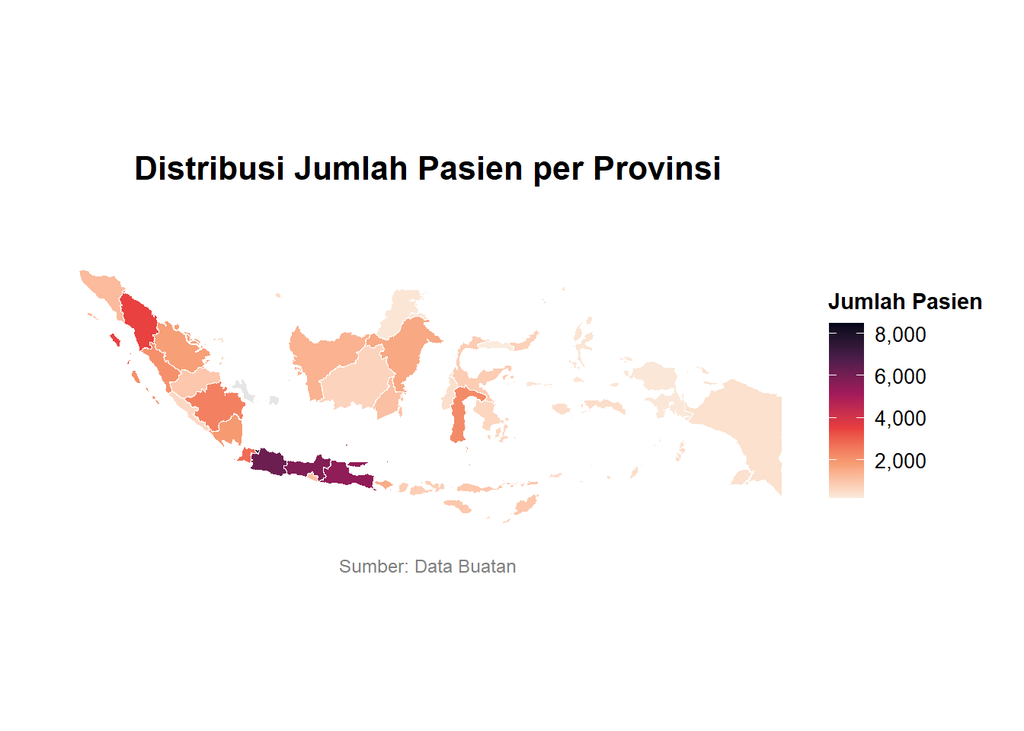

```r
# Data provinsi - sesuaikan dengan nama di shapefile
provinsi_data <- data.frame(
  NAME_1 = c(
    "Aceh", "Sumatera Utara", "Sumatera Barat", "Riau", "Jambi",
    "Sumatera Selatan", "Bengkulu", "Lampung", "Kepulauan Riau",
    "Jakarta Raya", "Jawa Barat", "Jawa Tengah", "Yogyakarta", "Jawa Timur", "Banten",
    "Bali", "Nusa Tenggara Barat", "Nusa Tenggara Timur",
    "Kalimantan Barat", "Kalimantan Tengah", "Kalimantan Selatan", "Kalimantan Timur", "Kalimantan Utara",
    "Sulawesi Utara", "Sulawesi Tengah", "Sulawesi Selatan", "Sulawesi Tenggara", "Gorontalo", "Sulawesi Barat",
    "Maluku", "Maluku Utara",
    "Papua Barat", "Papua", "Papua Selatan"
  ),
  Jumlah_Pasien = c(
    1200, 3500, 2100, 1800, 950,
    2400, 600, 1900, 500,
    8500, 6200, 5800, 1100, 5500, 2800,
    1500, 800, 950,
    1400, 700, 1100, 1600, 300,
    750, 850, 2200, 650, 200, 450,
    500, 350,
    280, 420, 180
  ),
  Avg_Age = c(
    48, 52, 45, 47, 44,
    49, 42, 46, 41,
    51, 50, 48, 44, 49, 47,
    46, 43, 41,
    45, 40, 44, 47, 39,
    43, 41, 48, 42, 38, 40,
    44, 41,
    37, 39, 36
  ),
  Avg_BMI = c(
    26.2, 27.8, 25.9, 26.5, 24.8,
    28.1, 24.5, 26.8, 25.2,
    29.5, 28.8, 27.2, 26.1, 27.9, 28.3,
    27.5, 25.8, 24.2,
    26.0, 24.9, 26.4, 27.1, 24.0,
    25.5, 24.3, 27.6, 25.2, 23.8, 24.7,
    25.9, 24.6,
    23.5, 24.1, 22.8
  ),
  Avg_Visits = c(
    4.2, 5.8, 3.9, 4.5, 3.2,
    5.1, 3.0, 4.8, 2.8,
    7.2, 6.5, 5.5, 4.1, 5.9, 5.2,
    4.8, 3.5, 3.1,
    3.8, 2.9, 3.6, 4.2, 2.5,
    3.3, 2.8, 5.0, 3.1, 2.2, 2.7,
    3.4, 2.9,
    2.1, 2.6, 1.8
  ),
  Avg_Billing = c(
    3.2, 4.5, 2.8, 3.5, 2.2,
    3.8, 1.9, 3.1, 2.5,
    6.8, 5.5, 4.2, 3.0, 4.8, 4.1,
    3.6, 2.4, 2.1,
    2.9, 2.0, 2.6, 3.3, 1.8,
    2.3, 2.0, 3.9, 2.2, 1.5, 1.9,
    2.5, 2.1,
    1.6, 1.9, 1.2
  ),
  stringsAsFactors = FALSE
)

# Aggregate shapefile by province (NAME_1): jika menggunakan shp level 2 untuk kabupaten
#indonesia_provinces <- indonesia_map %>%
 # group_by(NAME_1) %>%
  #summarise(geometry = st_union(geometry))

# Merge data dengan shapefile
map_data <- indonesia_map %>%
  left_join(provinsi_data, by = "NAME_1")

# Function untuk buat choropleth map
make_choropleth_map <- function(data, fill_var, title, subtitle,
                                color_palette = "viridis", legend_name,
                                label_fn = NULL, direction = 1) {

  p <- ggplot(data) +
    geom_sf(aes(fill = !!sym(fill_var)), color = "white", linewidth = 0.3) +

    scale_fill_viridis_c(
      option = color_palette,
      name = legend_name,
      labels = if (!is.null(label_fn)) label_fn else waiver(),
      direction = direction,
      na.value = "grey90"
    ) +

    labs(
      title = title,
      subtitle = subtitle,
      caption = "Sumber: Data Buatan"
    ) +

    theme_void() +
    theme(
      plot.title = element_text(size = 16, face = "bold", hjust = 0.5, margin = margin(b = 5)),
      plot.subtitle = element_text(size = 12, color = "gray30", hjust = 0.5, margin = margin(b = 15)),
      plot.caption = element_text(size = 9, color = "gray50", hjust = 0.5, margin = margin(t = 10)),
      legend.position = "right",
      legend.title = element_text(size = 11, face = "bold"),
      legend.text = element_text(size = 10),
      plot.background = element_rect(fill = "white", color = NA),
      panel.background = element_rect(fill = "white", color = NA),
      plot.margin = margin(20, 20, 20, 20)
    )

  return(p)
}

# Plot 1: Jumlah Pasien
plot1 <- make_choropleth_map(
  data = map_data,
  fill_var = "Jumlah_Pasien",
  title = "Distribusi Jumlah Pasien per Provinsi",
  subtitle = "",
  color_palette = "rocket",
  legend_name = "Jumlah Pasien",
  label_fn = comma,
  direction = -1
)

print(plot1)
```

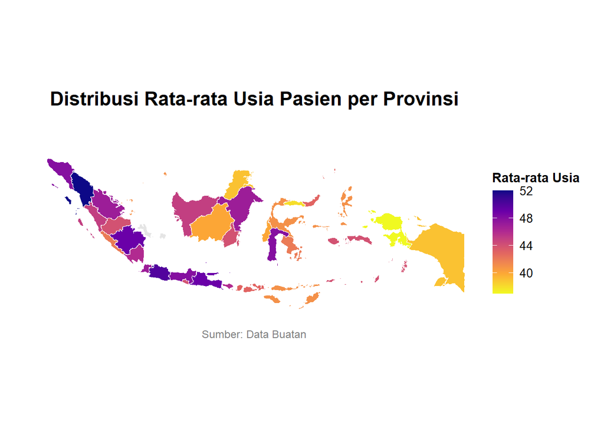

```r
ggsave("choropleth_jumlah_pasien.png", plot1, width = 12, height = 8, dpi = 300, bg = "white")

# Plot 2: Rata-rata Usia
plot2 <- make_choropleth_map(
  data = map_data,
  fill_var = "Avg_Age",
  title = "Distribusi Rata-rata Usia Pasien per Provinsi",
  subtitle = "",
  color_palette = "plasma",
  legend_name = "Rata-rata Usia",
  direction = -1
)

print(plot2)
```

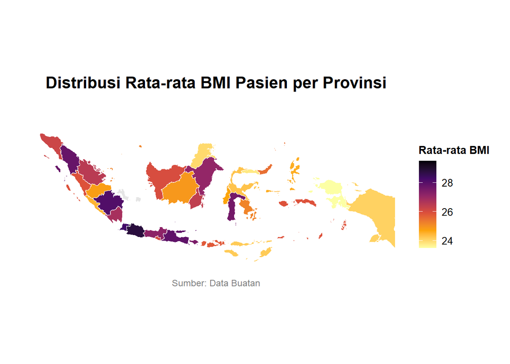

```r
ggsave("choropleth_avg_age.png", plot2, width = 12, height = 8, dpi = 300, bg = "white")

# Plot 3: Rata-rata BMI
plot3 <- make_choropleth_map(
  data = map_data,
  fill_var = "Avg_BMI",
  title = "Distribusi Rata-rata BMI Pasien per Provinsi",
  subtitle = "",
  color_palette = "inferno",
  legend_name = "Rata-rata BMI",
  direction = -1
)

print(plot3)
```

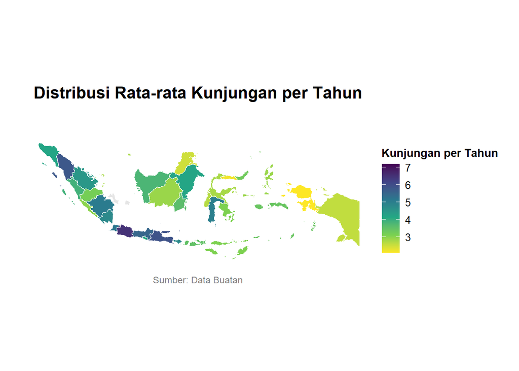

```r
ggsave("choropleth_avg_bmi.png", plot3, width = 12, height = 8, dpi = 300, bg = "white")

# Plot 4: Rata-rata Kunjungan
plot4 <- make_choropleth_map(
  data = map_data,
  fill_var = "Avg_Visits",
  title = "Distribusi Rata-rata Kunjungan per Tahun",
  subtitle = "",
  color_palette = "viridis",
  legend_name = "Kunjungan per Tahun",
  direction = -1
)

print(plot4)
```

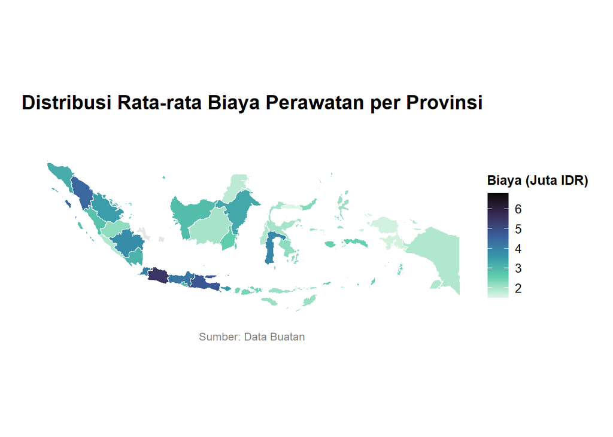

```r
ggsave("choropleth_avg_visits.png", plot4, width = 12, height = 8, dpi = 300, bg = "white")

# Plot 5: Rata-rata Biaya
plot5 <- make_choropleth_map(
  data = map_data,
  fill_var = "Avg_Billing",
  title = "Distribusi Rata-rata Biaya Perawatan per Provinsi",
  subtitle = "",
  color_palette = "mako",
  legend_name = "Biaya (Juta IDR)",
  direction = -1
)

print(plot5)
```

```r
ggsave("choropleth_avg_billing.png", plot5, width = 12, height = 8, dpi = 300, bg = "white")
```

# Tugas

1. Buat 2 plot untuk visualisasi nilai data, 2 plot untuk visualisasi sebaran data, dan 2 plot visualisasi perbandingan sebaran data beserta *interpretasinya*. Bebas pilih data dan plot apa saja.
2. Opsional: bisa buat visualisasi tambahan juga seperti word cloud dan map chart untuk nilai tambahan.
3. Tugas dikumpulkan paling lambat Selasa jam 23.59 di link: https://ipb.link/tugas-pertemuan2-prak-visdat dalam format .html atau .pdf (Format file: NIM_Nama_Tugas Pertemuan 2)